# Project - Analiza mocy testów zgodności próbki z rozkładów mieszanych

Karolina Grzanka

6/02/2019

## Wprowadzenie

#### Opis projektu

Tematem projektu jest stworzenie funkcji symulującej próbkiz rozkładów mieszanych oraz analiza mocy testów zgodności i rangowych, dla próbek otrzymanych w ten sposób.

Analiza korzystać będzie ze stworzonego specjalnie skryptu funkcji **rmix** do tworzenia próbki o rozkładanie mieszanym, który zawiera odpowiednie parametry:

- **N** -> długość próby
- **family_1** -> pierwszy typ rozkładu
- **par_1** -> wektor parametrów pierwszego rozkładu
- **family_2** -> drugi typ rozkładu
- **par_2** -> wektor parametrów drugiego rozkałdu
- **p** -> prawdopodobieństwo pierwszego rozkładu

```r
rmix <- function(n, family_1, par_1 , family_2, par_2, p){

  index <- sample(c(1,2), n, prob = c(p, 1-p), replace = T)

  #ilo?? liczb, kt?re b?d? pochodzi? z rozk?adu typu family_1
  sum1 <- length(which(index == 1))
  #ilo?? liczb, kt?re b?d? pochodzi? z rozk?adu typu family_2
  sum2 <- length(which(index == 2))

  if(family_1 == "norm"){
    sample_1 <- rnorm(sum1, mean = par_1[1], sd = par_1[2])
  } else if(family_1 == "t"){
    sample_1 <- rt(sum1, dt = par_1[1])
  } else if(family_1 == "binom"){
    sample_1 <- rbinom(sum1, size = par_2[1], prob = par_2[2])
  } else if(family_1 == "poisson"){
    sample_1 <- rpois(sum1, lambda = par_1[1])
  }

  if(family_2 == "norm"){
    sample_2 <- rnorm(sum2, mean = par_2[1], sd = par_2[2])
  } else if(family_2 == "t"){
    sample_2 <- rt(sum2, df = par_2[1])
  } else if(family_2 == "binom"){
    sample_2 <- rbinom(sum2, size = par_2[1], prob = par_2[2])
  } else if(family_2 == "poisson"){
    sample_2 <- rpois(sum2, lambda = par_2[1])
  }
  c(sample_1, sample_2)
}
```

Dalsza analiza będzie skłądać się z druch części:  
1. Analiza mocy testów zgodności dla mieszkanki dwóch rozkładów normalych  
2. Anlaiza mocy testu Wilcoxona dla mieszanki dwóch rozkałdów Poisonna.

#### Opis testów

W pierwszej części analizy wykorzystane zostaną 3 testy:

1. Test Shapiro-Wilka: *shapiro.test(x)* Jest to jeden z najpopularniejszych testów wykorzystywanych do badania normalności danych.  
   Hipoteza zerowa i alternatywna w teście Shapiro-Wilka ma następującą postać:  
   H0: Próba pochodzi z populacji o rozkładzie normalnym  
   H1: Próba nie pochodzi z populacji o rozkładzie normalnym.
2. Test Jarque-Bera: *jarque.bera.test(x)* Jest to test, który testuje wartość normalności przy użyciu statystyki Jarque-Bera. Test ten wykorzystuje wartości trzeciego i czwartego momentu centralnego.  
   Hipoteza zerowa i alternatywna w teście Jarque-Bera ma następującą postać:  
   H0: Próba pochodzi z rozkładu normalnego  
   H1: Próba nie pochodzi z rozkładu normalnego
3. Test Adersona-Darlinga: **ad.test(x)**  
   Jeden z testów statystycznych zgodności rozkładu z zadanym rozkładem wzorcowym. Zwykle stosuje się go do sprawdzenia zgodnosci z rozkładem normalnym. Hipoteza zerowa i alternatywna w teście Adersona-Darlinga ma następującą postać:  
   H0: Próba pochodzi z rozkładu wzorcowego H1: Próba nie pochodzi z rozkładu wzorcowego

W drógiej części wykorzystany zostanie test:

4. Test Wilcoxona: **wilcox.test(x, y)**  
   Jest nieparametryczną alternatywą dla testu t-Studenta dla przypadku dwóch równolicznych próbek dających się policzyć w pary. Często używa się tego testu do porównywania danych zebranych przed i po eksperymencie, w celu zbadania, czy nastąpiła istotna statystycznie zmiana. Hipoteza zerowa i alternatywna w teście Wilcoxona ma następującą postać:  
   H0: Nie ma różnic między pomiarami H1: Istnieją rożnice miedzy pomiarami

## Analiza mocy testów zgodności dla mieszkanki dwóch rozkładów normalych

```r
# Import niezbędnych bibliotek
library(dplyr)
library(tidyr)
library(ggplot2)
library(tseries)
library(nortest)
```

Hipotezy jakie będą sprawdzane w poniższych badaniach to wpływ różnych czynników na moc testów:

1. **W zależności od zmiany długości próby n:**  
   H0: wraz ze zwiększaniem długości próby n rośnie moc testu  
   H1: wraz ze zwiększaniem długości próby n maleje moc testu

W powyższym przypadku spodziewamy sie braku podstwa do odrzuceniach hipotezy zerowej.

2. **W zależności od zmiany prawdopodobieństwa:**  
   H0: wraz ze zwiekszaniem prawdopodobieństwa rośnie moc testu  
   H1: wraz ze zwiekszaniem prawdopodobieństwa maleje moc testu

W powyższym przypadku spodziewamy się braku podstwa do odrzuceniach hipotezy zerowej.

3. **W zależności od zmiany parametru par_1:**  
   H0: wraz ze zwiększaniem parametru par_1 rośnie moc testu  
   H1: wraz ze zwiększaniem parametru par_1 maleje moc testu

W powyższym przypadku spodziewamy sie braku podstwa do odrzuceniach hipotezy zerowej.

4. **W zależności od zmiany parametru par_2:**  
   H0: wraz ze zwiększaniem parametru par_2 rośnie moc testu  
   H1: wraz ze zwiększaniem parametru par_2 maleje moc testu

W powyższym przypadku spodziewamy sie braku podstwa do odrzuceniach hipotezy zerowej.

#### 1. Badanie wpływu zmiany długości próby (n) i pradopodobieństwa (p) pierwszgo rozkłądu na moc 3 testów

Wprowadzenie wartości do poszczególnych zmiennych:

```r
#ilość symulacji
N <- 500
#dlugość próby
n <- seq(40, 100, by = 4)
#typ rozkładu 1
family_1 <- "norm"
#typ rozkładu 2
family_2 <- "norm"
#prawdopodobienstwo pierwszego rozkładu
p <- c(.35, .55, .65)
#parametry1
par_1 <- c(2, 1)
#parametry2
par_2 <- c(4, 3)
#nazwa testu
name <- c("Test Shapiro-Wilka", "Test Andersona-Darlinga", "Test Jarque-Bera")
```

Następnie za pomoca funkcji **expand.grid** tworzę ramkę danych wszystkich kombinacji o nazwie ‘params’ z każdą możliwą trójką z badanych wartości.

Dla każdej trójki danych z pomocą odpowiedniej funkcji (shapiro.test, ad.test lub jarque.bera.test) obliczana jest moc testów i za pomocą **sapply** dołączana do wektora **powers**

Kolejno tworzona jet ramka danych **power_df**, do której przepisujemy ramkę **params** i dla każdej 3 danych w nowej kolumnie o nazwie **power** dopasowywana jest wyliczona moc z wektora **powers**:

Wizualizacja wyników: Tworzorzone jest zestawienie 3 wykresów dla każdego z podanych na początku wartości prawdopodobieństwa (p). Na osi poziomej X znajduje się długość próby (n), a na osi pionowej Y moc testu (power).

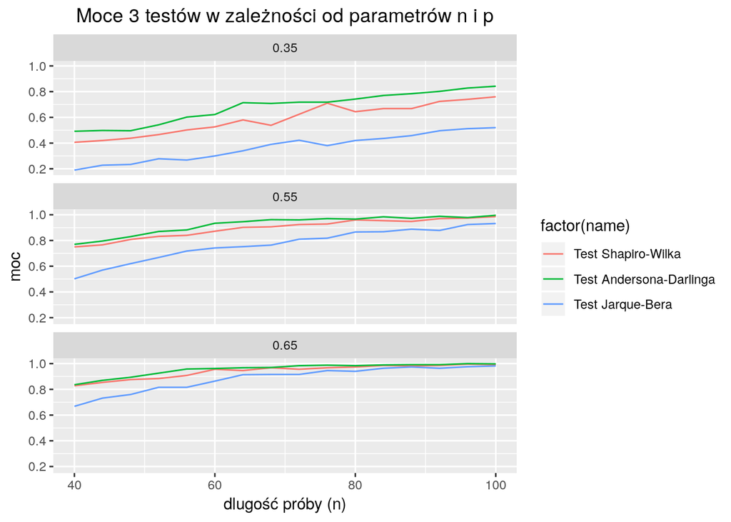

*Interpretacja*  
W obu rozważanych przypadkach nie ma podstaw do odrzucenia hipotez zerowych, gdyż moc testu znacząco rośnie wraz ze zwiekszaniem długości próby (`n`) oraz wraz ze zwiększaniem prawdopodobieństwa pierwszego rozkładu (`p`).

Test Andersona-Darlinga cechuje się najwiðkszą mocą, natomiast test Jarque-Bera wypada w tym przypadku najsłabiej.

#### 2. Badanie wpływu zmiany pierwszego elementu wektora par_1 na moc 3 testów

Wprowadzenie wartości do poszczególnych zmiennych:

```r
#dlugo?? próby
n <- c(40, 100, 150)
#prawdopodobienstwo pierwszego rozkładu
p <- .65
#pierwszy parametr par_1
paramki <- seq(2, 25, by = 1)
#parametry par_2
par_2 <- c(8, 3)
```

Następnie tworzymy ramkę power_df, analogicznie do powyższej części

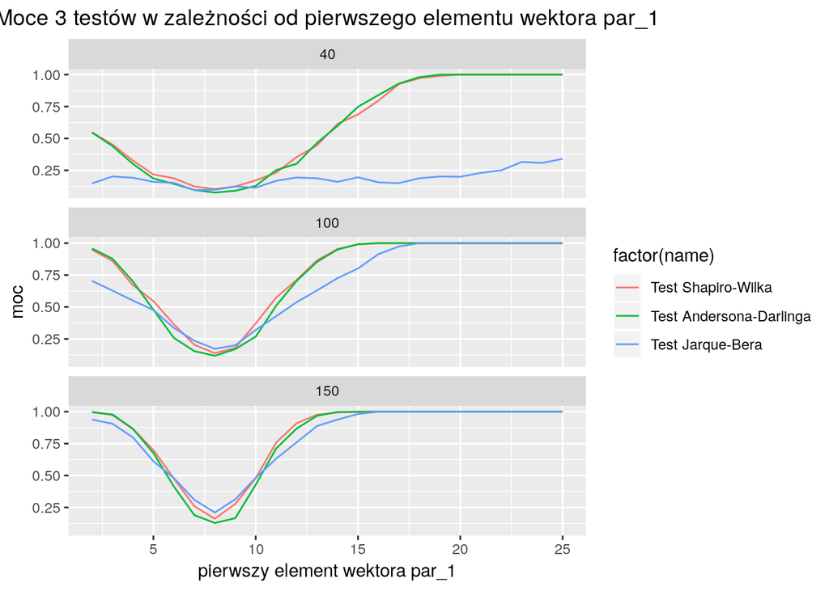

*Interpretacja*  
Zgodnie z przewidywaniami nie ma podstaw do odrzucenia hipotezy zerowej, moc testu maleje wraz ze zwiększaniem pierwszwego elementu wektora par_1 dla wartości miejszych od `8` oraz rośnie wraz ze zwiększaniem pierwszwego elementu wektora par_1 dla wartości wiśkszych od `8`. Moc jest najni?sza w punkcie r?wnym `8`, dzieje się tak ponieważ w tym miejscu wartości oczekiwane dwóch rozkładów są takie same, więc rozkłady nie różnią się znacząco. Dla długości próby równej `40` możemy zaobserować, że test Jarque-Bera cechuje się najmniejszą mocą.

#### 3. Badanie wpływu zmiany drugiego elementu wektora par_1 na moc 3 testów

Wprowadzenie wartości do poszczególnych zmiennych:

```r
#długość próby
n <- c(40, 100, 150)
#prawdopodobienstwo pierwszego rozkładu
p <- .65
#drugi parametr par_1
paramki <- seq(5, 10, by = .15)
#parametry par_2
par_2 <- c(8, 3)
```

Następnie tworzymy ramkę power_df, analogicznie do powyższej części

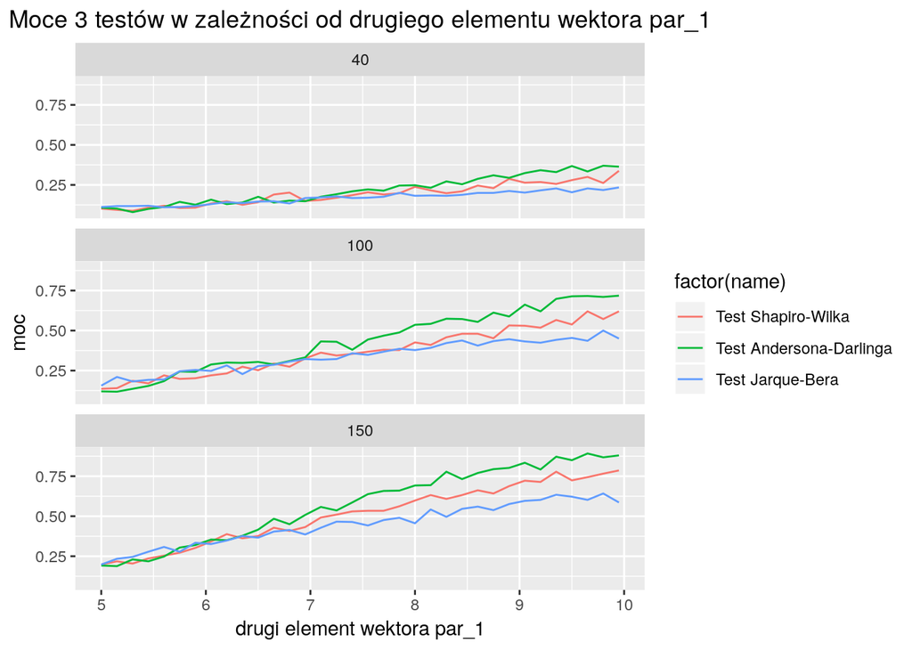

*Interpretacja*  
Nie ma podstaw do odrzucenia hipotezy H0, gdyż zmiana drugiego parametru pierwszego wektora `par_1` powoduje stopniowy wzrost mocy testów. Najlepiej sprawdza się tutaj test Andersona-Darlinga, natomiast najsłabszy jest ponownie test Jarque-Bera.

#### 4. Badanie wpływu zmiany pierwszego elementu wektora par_2 na moc 3 testów

Wprowadzenie wartości do poszczególnych zmiennych:

```r
#długość próby
n <- c(40, 100, 150)
#prawdopodobienstwo pierwszego rozkładu
p <- .65
#parametry par_1
par_1 <- c(7, 2)
#pierwsze elementy par_2
paramki <- seq(3, 11, by = .2)
```

Następnie tworzymy ramkę power_df, analogicznie do powyższej części

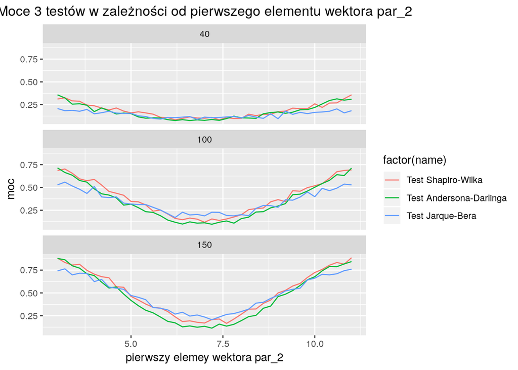

*Interpretacja*  
Są podstawy do odrzucenia hipotezy zerowej, gdyż zmiana pierwszego parametru drugiego wektora `par_2` pododuje spadek mocy dla wartosci zbliżających się do `7` z lewej strony oraz stopniowy wzrost mocy dla wartości oddalających się od `7` z prawej. W punkcie, w którym wartości `par_1` i `par_2` są sobie równe moce testów zbliżają się do zera, co wynika z tego, że mieszany rozkład będzie prawie taki sam jak ten, z którym badamy zgodność. Wszystkie 3 testy mają podobne moce.

#### 5. Badanie wpływu zmiany drugiego elementu wektora par_2 na moc 3 testów

Wprowadzenie wartości do poszczególnych zmiennych:

```r
#długość próby
n <- c(40, 100, 150)
#prawdopodobienstwo pierwszego rozk?adu
p <- .65
#parametry par_1
par_1 <- c(7, 3)
#drugie elementy par_2
paramki <- seq(1, 5, by = .2)
```

Następnie tworzymy ramkę power_df, analogicznie do powyższej części

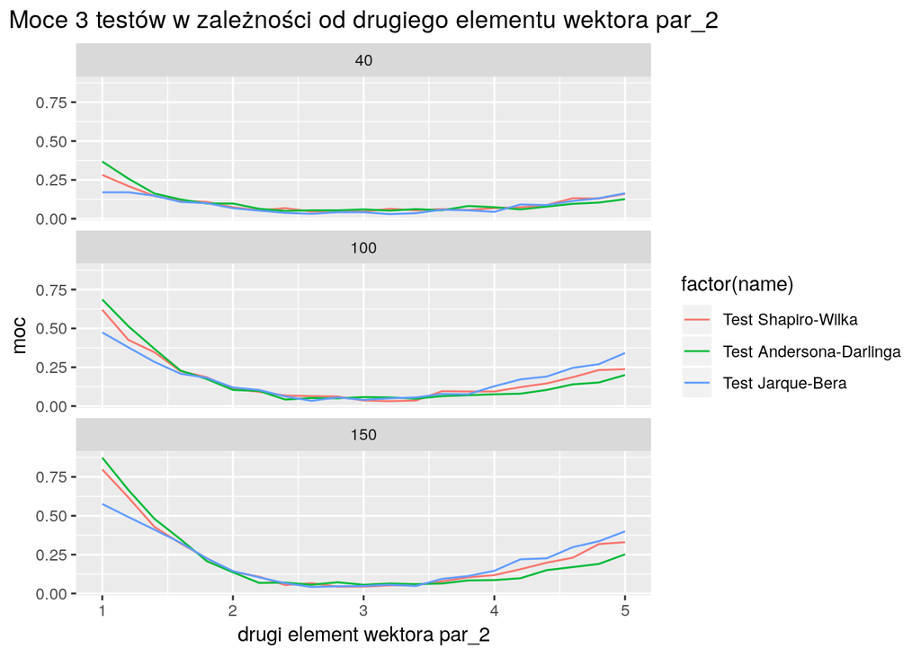

*Interpretacja*  
Są podstawy do odrzucenia hipotezy H0, gdyż zmiana drugiego parametru drugiego wektora `par_2` pododuje spadek mocy dla wartości zbliżających się do `3` z lewej strony praz stopniowy wzrost mocy dla wartości oddalających się od `3` z prawej. Wszystkie 3 testy mają podobne moce.

*Wnioski ogólne* Porównując moce testów między sobą na podstawie powyższych wykresów, ciężko stwierdzić, który spośród nich cechuje się największą dokładnością. Jednak w większości przypadków test Jarque-Bera odznaczał się najmniejszą mocą, natomiast najbardziej dokłądny był test Andersona-Darlinga.

## Anlaiza mocy testu Wilcoxona dla mieszanki dwóch rozkałdów Poisonna.

W tym zadaniu spradzamy moc testu **Wilcoxona** dla zmiennych z rozkładu **Poissona** dla zadanych parametrów, tak by stwierdzić jak zmienia się moc w zalełości od `p, par_2 i n`. Na początek wprowadzamy wartości do zmiennych, które będą przekazywane do funkcji **rmix**. Przyjmujemy, że zmienna `par_1` nie zmienia się i jest równa 8.

Obliczenia wykonane w poniższej analizy będą miały na celu stwierdzenie prawidłowości następujących hipotez:

- **W zależności od zmiany poziomu prawdopodobieństwa wystąpienia zmiennych z 1 rozkładu:**  
  H0: wraz ze zwiększaniem prawdopodobie?stwa maleje moc testu  
  H1: wraz ze zwiększaniem prawdopodobie?stwa rośnie moc testu

W powyższym przypadku spodziewamy sie braku podstwa do odrzuceniach hipotezy zerowej.

- **W zale?nosci od zmiany parametru par_2 - lambdy:**  
  H0: wraz ze zwiększaniem par_2 rośnie moc testu  
  H1: wraz ze zwiększaniem par_2 maleje moc testu

W powyższym przypadku spodziewamy sie braku podstwa do odrzuceniach hipotezy zerowej.

- **W zależności od zmiany długości próby:** H0: wraz ze zwiększaniem długości próby rośnie moc testu  
  H1: wraz ze zwiększaniem długości próby maleje moc testu

W powyższym przypadku spodziewamy sie braku podstwa do odrzuceniach hipotezy zerowej.

Wprowadzenie wartości do poszczególnych zmiennych:

```r
#ilość symulacji
N <- 200
#dlugołci próby
n <- seq(10, 310, by = 20)
#typ rozkładu 1
family_1 <- "poisson"
#parametr par_1
par_1 <- c(8)
#typ rozkładu 2
family_2 <- "poisson"
#parametr - lambda
par_2 <- c(1:25)
#prawdopodobienstwa
p <- c(.40, .55, .75)
```

Funkcją **expand.grid** tworzymy ramkę danych dla wszystich możliwych kombinacji zmiennych n, par_2 i p.

Po ustawieniu ziarna generatora na 20, dla każdej trójki danych z pomocą odpowiedniej funkcji **wilcox.test** obliczana jest moc testów i za pomocą **sapply** dołączana do wektora **powers**.

Tworzymy nową ramkę danych o nazwie **wilcox_df**, którą będziemy wykorzystywać do sporządzenia wykresów. Ramka danych zawierać będzie te same wartości co ramka **params** z dodatkową kolumną o nazwie **power**, zawierającą wyliczone wartości mocy dla każdych możliwych 3 danych.

Za pomocą funkcji **ggplot** tworzymy wykres przedstawiający zaleąności pomiędzy n, par_2 oraz p.

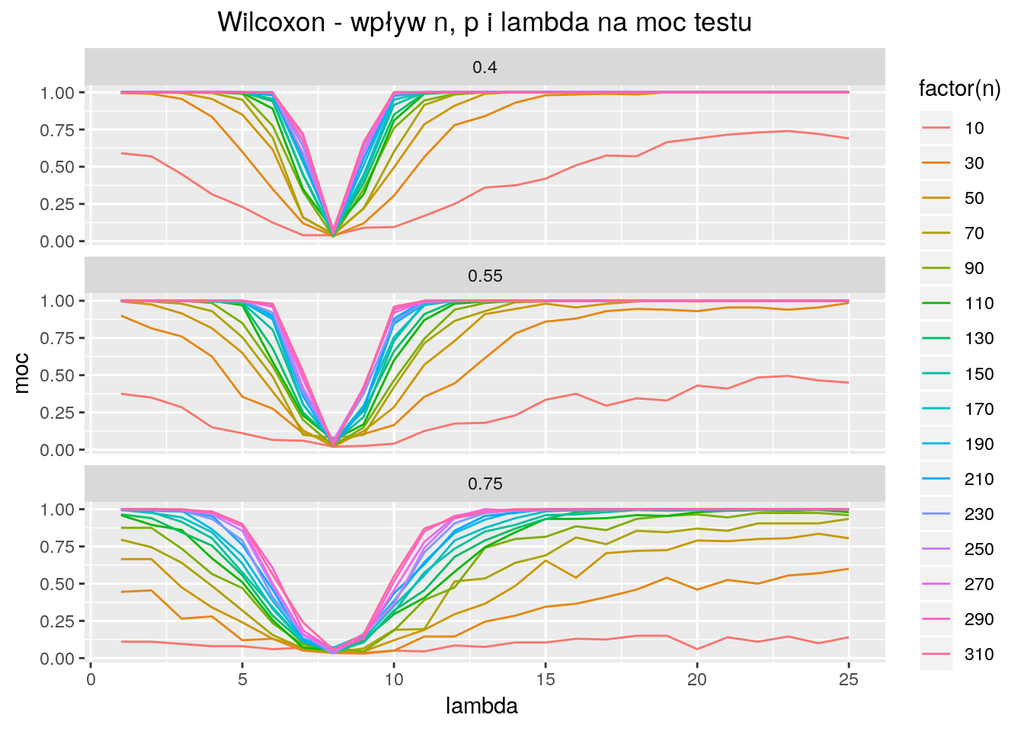